# Population Reconstruction Example. Thailand

Mark C. Wheldon

2018-10-23

**Affiliations:** MCW: UN Population Division, wheldon@un.org.

**Acknowledgements:** This is joint work with Adrian E. Raftery (Univ. of Washignton), Samuel J. Clark (Ohio State Univ.), and Patrick Gerland (UN Population Division).

**Disclaimer:** The views and opinions expressed in this work are those of the authors and do not necessarily represent those of the United Nations. This work has not been formally edited and cleared by the United Nations.

# 1 Background

Bayesian population reconstruction was introduced in the following series of articles: Wheldon et al. (2013), Wheldon et al. (2016), Wheldon et al. (2015). There is an associated *R* package Wheldon (2014) on *CRAN* but a more up-to-date version is Wheldon (2017).

In this vignette I will use wrapper functions that make things much easier. These are available from (https://github.com/markalava/Bayesian-Reconstruction/popReconstructWrappers). They are based on two-sex reconstruction and the example of Thailand from (Wheldon et al. 2015).

# 2 Set-Up

```r
## Install the package
library("devtools")

## Not run
## devtools::install_github(repo = "markalava/Bayesian-Reconstruction/workshops/ALAP_2018/popReconstructWrappers/package")

library(popReconstructWrappers)

## Create a directory for results
dir.create("poprecon")
setwd("poprecon")
```

# 3 Inputs

The inputs for the example are bundled with the package. Use `data()` to access them.

```r
data("Thailand_Example")
```

```
## character(0)
```

The main inputs are initial estimates of

- fertility
- migration
- survival
- population counts in the baseline year
- population counts in subsequent years
- sex ratios at birth

by sex, age, and year, and life table ‘separation factors’ to separate cohort deaths into period deaths.

Proposal variances are additional inputs that control the efficiency of the MCMC algorithm.

## 3.1 Fertility Rates and SRBs

Fertility rates and SRBs are matrices with five-year periods as columns, age-groups as rows.

```r
asFertTHAI.mat[1:12, 1:5]
```

```
##          1960       1965       1970       1975        1980
## 0  0.00000000 0.00000000 0.00000000 0.00000000 0.000000000
## 5  0.00000000 0.00000000 0.00000000 0.00000000 0.000000000
## 10 0.00000000 0.00000000 0.00000000 0.00000000 0.000000000
## 15 0.05175459 0.06061538 0.06224863 0.06697348 0.056633004
## 20 0.24021806 0.23413036 0.22148542 0.21094695 0.163755256
## 25 0.28880806 0.27729894 0.24963584 0.19398416 0.154346419
## 30 0.27214926 0.25390511 0.21493142 0.15023581 0.103045913
## 35 0.21223853 0.19860950 0.16017444 0.10735185 0.060685573
## 40 0.11637142 0.12300785 0.09998354 0.05626398 0.041692712
## 45 0.02948599 0.03232336 0.02472358 0.02067992 0.008513132
## 50 0.00000000 0.00000000 0.00000000 0.00000000 0.000000000
## 55 0.00000000 0.00000000 0.00000000 0.00000000 0.000000000
```

## 3.2 Survival and Migration Proportions, Population Counts

The remaining inputs are lists of two components, “female” and “male”. Each component is a matrix with five-year periods as columns, age-groups as rows.

```r
lapply(asSurvTHAI.mat, "[", i = 1:3, j = 1:5)
```

```
## $female
##         1960      1965      1970      1975      1980
## 0  0.9142663 0.9237345 0.9377636 0.9546893 0.9692136
## 5  0.9612171 0.9621474 0.9724710 0.9805215 0.9857410
## 10 0.9899652 0.9911082 0.9923885 0.9936778 0.9954615
##
## $male
##         1960      1965      1970      1975      1980
## 0  0.9108313 0.9224748 0.9340966 0.9461544 0.9605498
## 5  0.9611747 0.9639159 0.9731235 0.9801511 0.9830052
## 10 0.9881956 0.9895983 0.9911646 0.9926470 0.9943731
```

# 4 Running the Reconstruction

1. Set the seed:

```r
set.seed(1)
```

2. Set the number of iterations. This will typically be in the 100,000s but here we do a quick run for a demonstration:

```r
n.iter <- 17
burn.in <- 3
```

3. Convert elicited relative errors to hyperparamaters:

```r
invGam.params <- make.hyper.params(absDev = list(fert = 0.1, surv = 0.1, mig = 0.2
             ,pop = 0.1, srb = 0.1)
             ,prob = list(fert = 0.9, surv = 0.9, mig = 0.9, pop = 0.9, srb = 0.9)
             ,alpha = list(fert = 0.5, surv = 0.5, mig = 0.5, pop = 0.5, srb = 0.5)
             ,s.star = unlist(asSurvTHAI.mat)
             )

invGam.params[1:2]
```

```
## $al.f
## [1] 0.5
##
## $be.f
## [1] 0.0001392358
```

4. Set the function arguments

```r
estModArgs <-
    list(## Algorithm parameters
        n.iter = n.iter, burn.in = burn.in

        ## Inputs:

        ## Inverse gamma parameters
       ,al.f = invGam.params$al.f
       ,be.f = invGam.params$be.f
       ,al.s = invGam.params$al.s
       ,be.s = invGam.params$be.s
       ,al.g = invGam.params$al.g
       ,be.g = invGam.params$be.g
       ,al.n = invGam.params$al.n
       ,be.n = invGam.params$be.n
       ,al.srb = invGam.params$al.srb
       ,be.srb = invGam.params$be.srb

        ## Initial estimates
       ,mean.f = asFertTHAI.mat
       ,mean.s = asSurvTHAI.mat
       ,mean.g = asMigTHAI.mat
       ,mean.b = baselineTHAI.mat
       ,mean.srb = srbTHAI.mat
       ,pop.data = censusTHAI.mat

        ## Start values
       ,start.f = asFertTHAI.mat
       ,start.s = asSurvTHAI.mat
       ,start.g = asMigTHAI.mat
       ,start.b = baselineTHAI.mat
       ,start.srb = srbTHAI.mat
       ,start.sigmasq.f = 5
       ,start.sigmasq.s = 5
       ,start.sigmasq.g = 5
       ,start.sigmasq.n = 5
       ,start.sigmasq.srb = 5

        ## Periods and age group size
       ,proj.periods = ncol(asFertTHAI.mat)
       ,age.size = 5

        ## Proposal variances and other
       ,prop.varcovar = thai.propvar
       ,verb = TRUE, progress.step = 1E3
    )
```

6. Run, then save the reconstruction:

```r
ThaiMcmc <- do.call(pop.est.sampler, args = estModArgs)
```

```
##
##
## total iterations = 20
## burn in = 3, stored = 17
##
## fert.rows =  4 5 6 7 8 9 10
## census years =  1970 1980 1990 2000
## vital rate years =  1960 1965 1970 1975 1980 1985 1990 1995
## projection years =  1960 1965 1970 1975 1980 1985 1990 1995 2000
##
## iter  quantity
## ----  --------
```

```r
save(ThaiMcmc, file = file.path("poprecon", "thai_mcmc.RData"))
```

## 4.1 Tuning

The MCMC algorithm needs to be tuned to ensure the chains have mixed well. This is indicated by Metropolis acceptance ratios. MCMC acceptance ratios between about 0.2 and 0.5 are acceptable. These can be plotted for each input parameter.

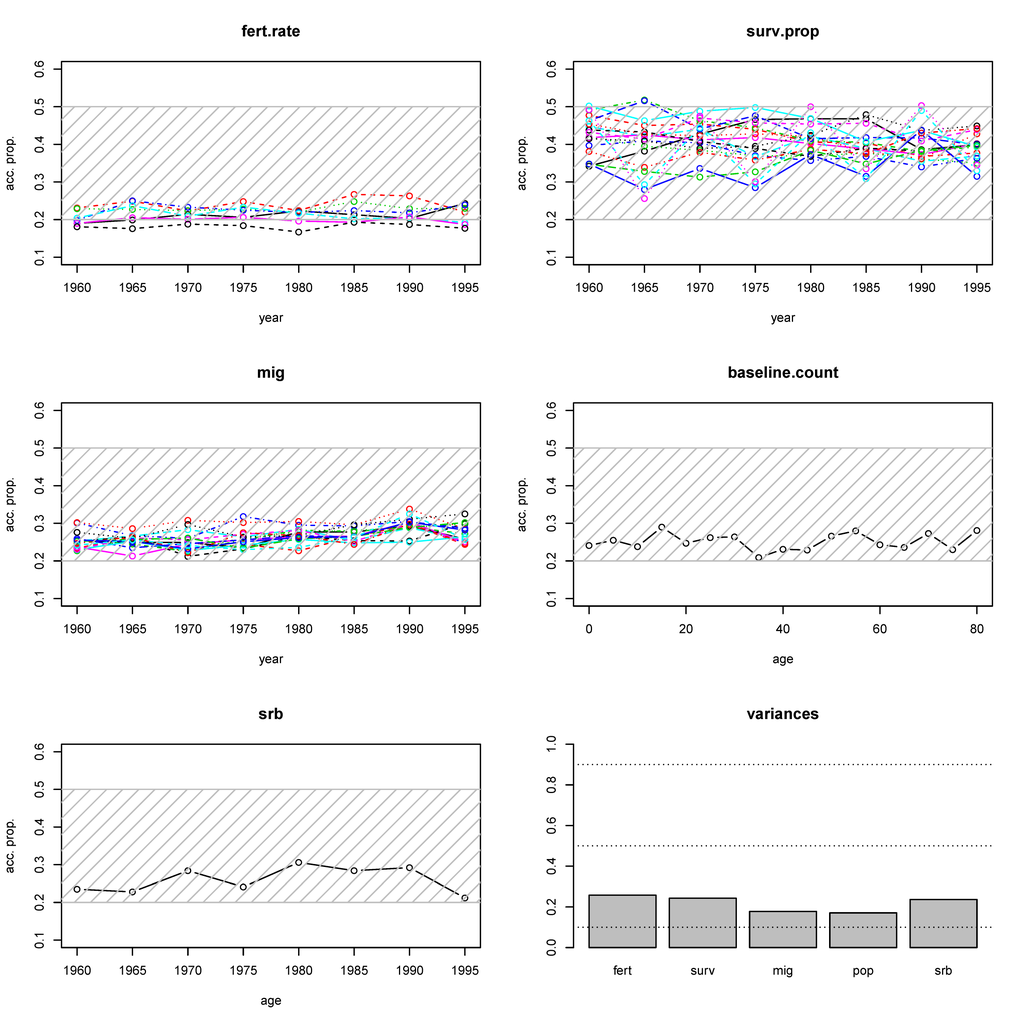

```r
## Not run (see below)
## plot.acceptance.props(ThaiMcmc)

## Not run
try(
    conditional.variances(ThaiMcmc)
    )
```

Suggestions for proposal variances are generated if they need to be altered. Finding good proposal variances is a matter of trial and error with short runs of the model.

## 4.2 Post-process

The output from the sampler, `ThaiMcmc`, contains the posterior distribution for the input parameters, namely fertiltiy rates, survival proportions, etc. To get posterior samples for other parameters, such as mortality rates, TFR, they can be transformed using `post.process.recon()`.

```r
ThaiCounts <- post.process.recon(ThaiMcmc
           ,sep.factors = list(female = thaiFemale.sf
                                 ,male = thaiMale.sf)
           ,name.pref = "Thai."
           ,name.suf = ""
             )
```

# 5 Generate Prior Distribution Samples

If you want to create plots that compare the prior and posterior distributions, run `sample.from.prior()`. Note: this can take a long time. These also need post-processing to get mortality rates, TFR, etc. Use `post.process.recon` again as below.

This method used as the joint distribution of the parameters under the prior is complicated by the need to ensure that the population remains positive; without this constraint, very extreme migration could imply negative populations. The distributions for rates, such as mortality rates, are also complicated because they depend not only on mortality parameters but also the size of the population at-risk at each age group and time period. Drawing a large, random sample saves us from having to work all this out by hand.

```r
ThaiPrior <-
    sample.from.prior(n.iter = 10, #Change to at least 1e3
                      al.f = invGam.params$al.f,
                      be.f = invGam.params$be.f,
                      al.s = invGam.params$al.s,
                      be.s = invGam.params$be.s,
                      al.g = invGam.params$al.g,
                      be.g = invGam.params$be.g,
                      al.n = invGam.params$al.n,
                      be.n = invGam.params$be.n,
                      al.srb = invGam.params$al.srb,
                      be.srb = invGam.params$be.srb,
                      mean.f = asFertTHAI.mat,
                      mean.s = asSurvTHAI.mat,
                      mean.g = asMigTHAI.mat,
                      mean.b = baselineTHAI.mat,
                      mean.srb = srbTHAI.mat,
                      age.size = 5,
                     name.pref = "Thai.",
                     name.suf = "")
```

```r
ThaiPriorCounts <- post.process.recon(ThaiPrior,
           sep.factors = list(female = thaiFemale.sf
                                 ,male = thaiMale.sf),
            name.pref = "Thai.",
            ,name.suf = "Prior"
             )
```

# 6 Summarizing Results

Prior and posterior marginal quantiles can be generated using `get.quantiles.recon`. You can request a number of different parameters:

```r
qrecon <-
    get.quantiles.recon(param = c("e0", "tfr",
                                  "total.mig.count",
                                  "cohort.nq0", "period.nq0", "IMR",
                                  "mort.rate", "mig.rate", "birth.count", "death.count",
                                  "surv.prop", "srb", "baseline.count"
                                  ),
                        results.recon = ThaiMcmc,
                        results.post.process.recon = ThaiCounts,
                        results.prior = ThaiPrior,
                        results.post.process.prior = ThaiPriorCounts
                        )
```

The quantiles are in a convenient form for plotting:

```r
head(qrecon)
```

```
##   param.2.5pctl param.10pctl param.50pctl param.90pctl param.97.5pctl    legend
## 1      62.07168     62.43945     63.08891     63.77216       64.02167 posterior
## 2      62.49240     62.56962     64.63050     65.25087       65.56667 posterior
## 3      65.64677     65.71425     66.48821     67.10602       67.48386 posterior
## 4      67.96062     68.03071     68.62723     69.12155       69.34509 posterior
## 5      70.02170     70.51932     71.72683     72.75420       72.88194 posterior
## 6      72.58588     72.67586     74.10027     74.56222       75.03734 posterior
##   year param age    sex
## 1 1960    e0  NA female
## 2 1965    e0  NA female
## 3 1970    e0  NA female
## 4 1975    e0  NA female
## 5 1980    e0  NA female
## 6 1985    e0  NA female
```

```r
## Look at a particular parameter:
head(subset(qrecon, param == "mort.rate"))
```

```
##     param.2.5pctl param.10pctl param.50pctl param.90pctl param.97.5pctl
## 169  0.0223832011  0.022462917  0.025578767  0.028145707    0.028321412
## 170  0.0019430720  0.002444299  0.003066957  0.003245484    0.003324335
## 171  0.0009973441  0.001286549  0.001492697  0.001637653    0.001802496
## 172  0.0015193773  0.001666833  0.001924387  0.002364114    0.002373242
## 173  0.0020638221  0.002372634  0.002942299  0.003509152    0.004050402
## 174  0.0022331045  0.003067107  0.003316431  0.004040984    0.004618684
##         legend year     param age    sex
## 169 init. est. 1960 mort.rate   0 female
## 170 init. est. 1960 mort.rate   5 female
## 171 init. est. 1960 mort.rate  10 female
## 172 init. est. 1960 mort.rate  15 female
## 173 init. est. 1960 mort.rate  20 female
## 174 init. est. 1960 mort.rate  25 female
```

```r
library(ggplot2)
```

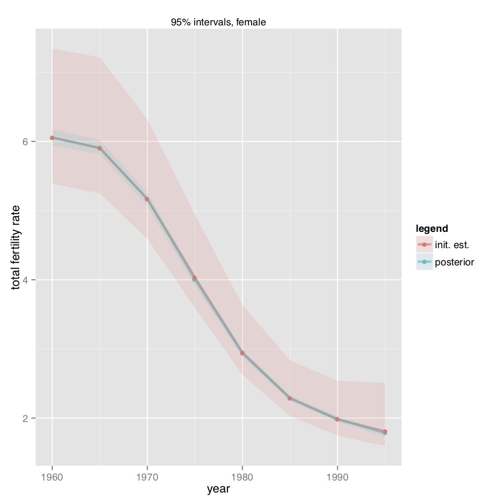

Figure 6.1: Prior and posterior 95% quantiles, and medians, for total fertility rate, Thailand, 1960–2000 (Wheldon et al. 2015).

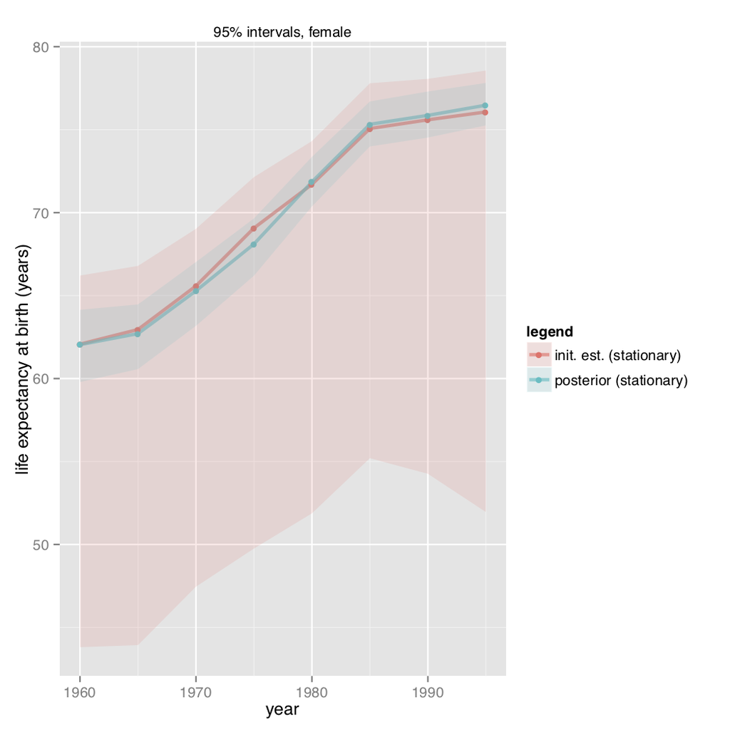

Figure 6.2: Prior and posterior 95% quantiles, and medians, for life expectancy at birth, females, Thailand, 1960–2000 (Wheldon et al. 2015).

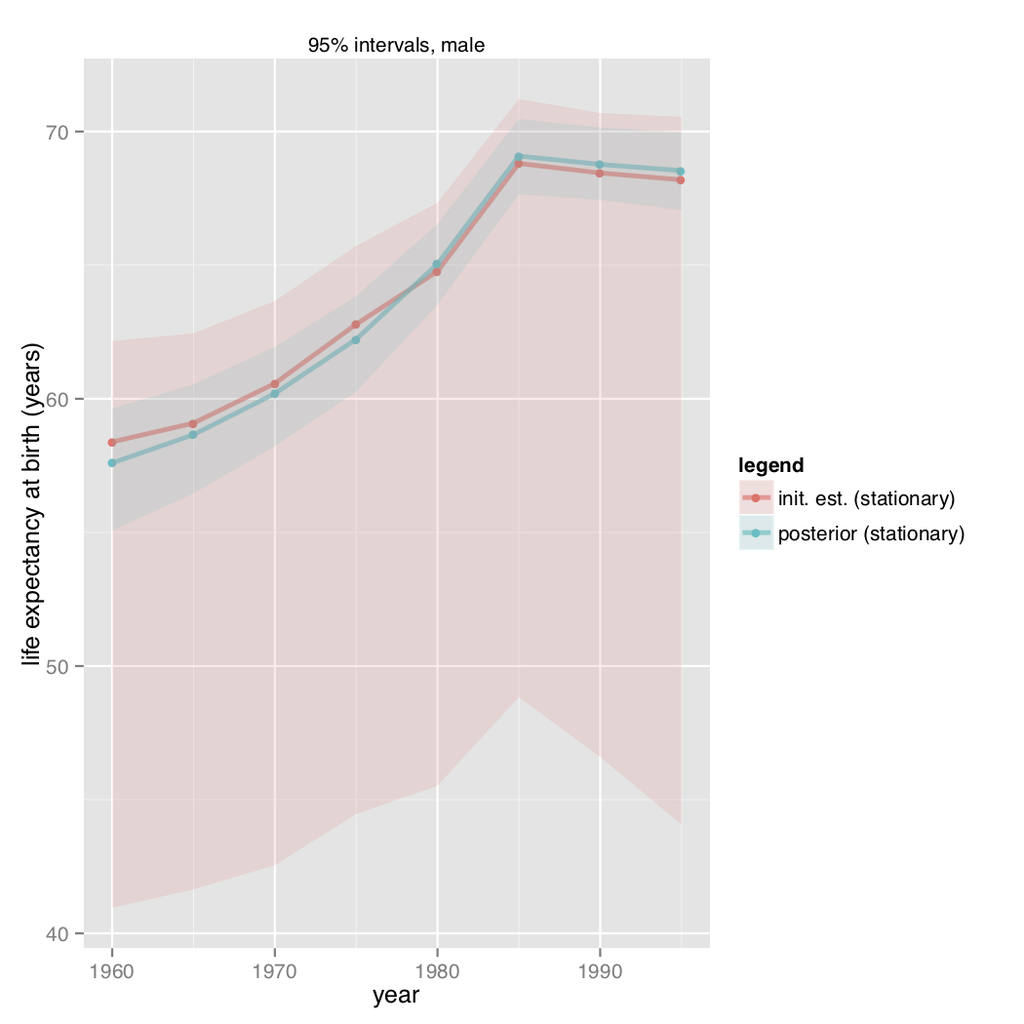

Figure 6.3: Prior and posterior 95% quantiles, and medians, for life expectancy at birth, males, Thailand, 1960–2000 (Wheldon et al. 2015).

```r
gp <-
    ggplot(subset(qrecon, param == "tfr"), aes(x = year, y = param.50pctl)) +
        geom_line(aes(col = legend), size = 1.1) + geom_point(aes(col = legend)) +
    geom_ribbon(aes(ymin = param.2.5pctl, ymax = param.97.5pctl, fill = legend), alpha = 0.2)
```

If you do not have the samples from the prior you can omit `results.prior` and `results.post.process.prior` (or set them to `NULL`) to get just the posterior quantiles.

# References

Wheldon, M. C. 2014. *popReconstruct* (version 1.0-4). Vienna, Austria. http://CRAN.R-project.org/package=popReconstruct.

———. 2017. *Bayesian-Reconstruction: Two-Sex Population Reconstruction*. https://github.com/markalava/Bayesian-Reconstruction/tree/master/Thailand_Example.

Wheldon, M. C., A. E Raftery, S. J. Clark, and P. Gerland. 2013. “Reconstructing Past Populations with Uncertainty from Fragmentary Data.” *Journal of the American Statistical Association* 108 (501): 96–110. https://doi.org/10.1080/01621459.2012.737729.

Wheldon, M. C., A. E. Raftery, S. J. Clark, and P. Gerland. 2015. “Bayesian Reconstruction of Two-Sex Populations by Age: Estimating Sex Ratios at Birth and Sex Ratios of Mortality.” *Journal of the Royal Statistical Society: Series A (Statistics in Society)* 178 (4): 977–1007. https://doi.org/10.1111/rssa.12104.

———. 2016. “Bayesian Population Reconstruction of Female Populations for Less Developed and More Developed Countries.” *Population Studies* 70 (1): 21–37. https://doi.org/10.1080/00324728.2016.1139164.